# ggplot2 - theme

Lim Wonki

2019. 06. 12.

### **사전준비 및 외부글꼴 적용하기**

무료배포 글꼴은 [여기](https://brunch.co.kr/@jade/203)에서 다운받아 설치 합니다.  
폰트를 적용하기 위해서는 다음과 같은 패키지와 라이브러리가 필요합니다.

```r
install.packages("extrafont")
library(extrafont)
```

아래 코드로 윈도우에 설치된 글꼴을 찾아 R로 가져옵니다. (단, y로 설치 동의)

```r
font_import(pattern = 'TmonMonsori') # 폰트 불러오기
font_import(pattern = 'Jalnan')
font_import(pattern = 'BMDOHYEON')
font_import(pattern = 'BM')
font_import(pattern = 'Binggrae')
```

이후 글꼴이름을 사용자가 원하는 이름으로 설정합니다.

```r
windowsFonts(hanna=windowsFont("BM HANNA 11yrs old")) # 폰트이름 변경
windowsFonts(dohyeon=windowsFont("BM DoHyeon"))
windowsFonts(jalnan=windowsFont("Jalnan"))
windowsFonts(tb=windowsFont("TmonMonsori Black"))
windowsFonts(binggrae=windowsFont("Binggrae Taom"))
windowsFonts(nbg=windowsFont("나눔바른고딕"))
```

테스트에 필요한 패키지와 라이브러리는 다음과 같습니다.

```r
install.packages("dplyr")
library(dplyr)
```

```r
install.packages("ggplot2")
library(ggplot2)
```

글꼴 적용 확인 코드는 다음과 같습니다.

```r
iris %>%
  ggplot(aes(x=Sepal.Length, y=Petal.Length, color=Species)) + # 색상을 Species 별로 설정
  geom_point() + # 산점도
  theme_bw(base_family = "나눔바른고딕", base_size = 10) + # 그래프의 백그라운드 색상을 흰색으로 바꾸고 기본 글꼴 적용
  theme(legend.position = "top") + # 범례 위치 설정
  labs(title="붓꽃 데이터 한글 글꼴 적용", color="붓꽃 종류") + # 타이틀 설정
  theme(plot.title = element_text(family = "jalnan", face = "bold", hjust = 0.5, size = 15, color = "grey20")) # 타이틀 서식
```

### **ggplot2 그래프 커스텀 하기**

### **목차**

0. 기본 그래프 만들기
1. 타이틀(Title) 커스텀 하기  
   1.1 타이틀 입력하고 꾸미기  
   1.2 타이틀 여러 줄로 나누기
2. 축(Axis) 커스텀 하기  
   2.1 축 타이틀 꾸미기  
   2.2 축 타이틀 바꾸기  
   2.3 축 타이틀에 수식 넣기  
   2.4 축 표현 범위 설정하기  
   2.5 축 텍스트 잘게 쪼개기  
   2.6 축 텍스트 바꾸기  
   2.7 축 텍스트 옆으로 눕히기  
   2.8 축 위치 바꾸기  
   2.9 Y축 2개 만들기
3. 범례(Legend) 커스텀 하기  
   3.1 범례 지우기  
   3.2 범례 꾸미기  
   3.3 범례 테두리 꾸미기  
   3.4 범례 위치 바꾸기  
   3.5 범례 위치를 그래프 안으로 넣기  
   3.6 범례 타이틀만 지우기  
   3.7 범례 타이틀 바꾸기
4. 그래프(Plot) 커스텀 하기  
   4.1 그래프 안에 글자/선/도형 넣기  
   4.2 그래프 X축, Y축 바꿔 그리기  
   4.3 흑백으로 나타내기  
   4.4 팔레트 적용하기  
   4.5 원하는 색상으로 바꾸기  
   4.6 테마 적용하기
5. 좌표계(coordinate) 커스텀 하기  
   5.1 좌표계란  
   5.2 coord_cartesian 함수  
   5.2.1 xlim과 ylim  
   5.2.2 expand  
   5.3.3 scale_x_continuous와 차이점

[부록] theme() 함수의 elements 설명

#### **0. 기본 그래프 만들기**

앞으로의 예제에 사용될 기본 그래프를 만듭니다.  
그래프에 사용되는 데이터는 “MASS” 패키지의 “Cars93” 데이터입니다.  
X축을 차량 가격, Y축을 마력, 색상을 차량 구동계로 설정하여 Jitter Plot을 그리는 기본 그래프를  
“Basic_Plot” 변수에 저장하여 반복해서 사용할 예정입니다.  
기본 그래프를 생성하는 코드와 결과는 다음과 같습니다.

```r
library(ggplot2)
library(MASS)    # dplyr 패키지 설치시 같이 설치됩니다.
```

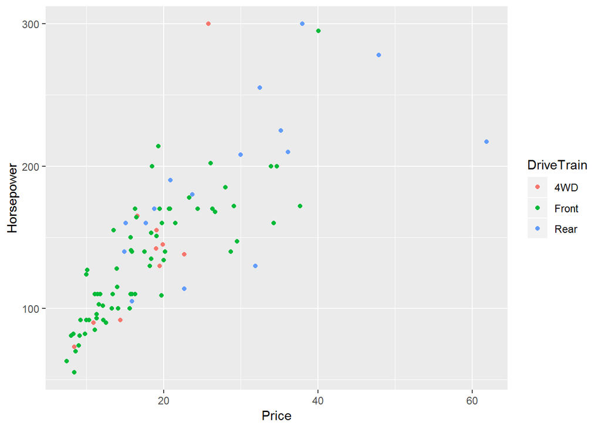

```r
data("Cars93")   # MASS 패키지에서 Cars93 데이터를 가져옵니다.

Basic_Plot <- ggplot(Cars93, aes(x=Price, y=Horsepower)) + # x: 가격, y: 마력
  geom_point(aes(colour=DriveTrain))  # 산점도를 그립니다.  색상은 차량 구동계 별로 그립니다.
```

#### **1. 타이틀(title) 커스텀 하기**

제일 처음 해볼 내용은 그래프의 타이틀을 커스텀 하는 부분입니다.  
본격적인 ggplot2를 커스텀하기 전에 먼저 각 부분의 명칭을 알아보고 갑시다.

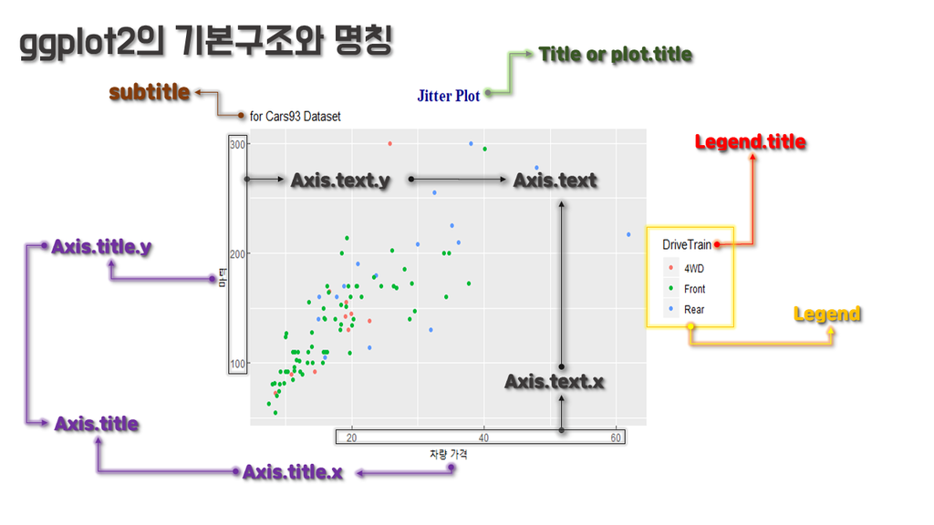

Graphic

##### **1.1 타이틀 입력하고 꾸미기**

plottitle, subtitle, axis.title 모두 labs 함수로 쉽게 입력이 가능합니다.  
타이틀을 꾸미기 위해서는 theme() 함수를 통해서 설정을 해주어야 합니다.  
(theme() 함수에 사용되는 element에 대한 설명은 부록에 작성되어 있습니다.)

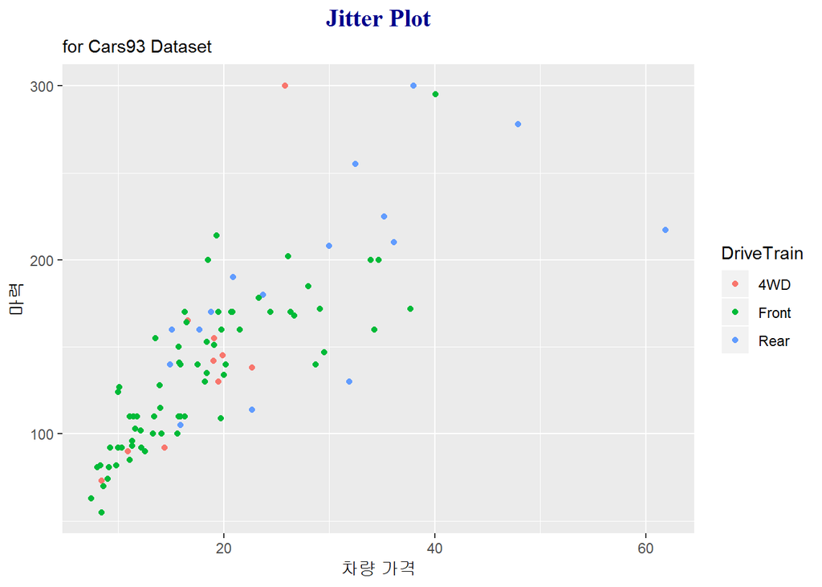

```r
Basic_Plot +
  labs(title="Jitter Plot", # plot 타이틀을 지정합니다.
       subtitle = "for Cars93 Dataset", # subtitle을 지정합니다.
       x = "차량 가격",   # x 축 타이틀(axis.title.x)을 변경합니다.
       y = "마력") +      # y 축 타이틀을 변경합니다.
  theme(plot.title = element_text(family = "serif", face = "bold", hjust = 0.5, size = 15, color = "darkblue"))   # plot title의 글씨체(family), 글씨 모양(face), 가운데 정렬(hjust), 크기(size), 색상(color)을 설정합니다. plot.subtitle로 서브타이틀 또한 커스텀이 가능합니다.  다만, 축 타이틀은 theme함수로 지정합니다.
```

##### **1.2 타이틀 여러 줄로 나누기**

타이틀이 장문일 경우에는 여러 줄로 나눠서 나타내는 것이 필요합니다.  
문장을 나누는 방법은 labs() 함수 내에서 타이틀을 입력하고 나누고 싶은 부분에서 `\n`을 입력하면 됩니다.

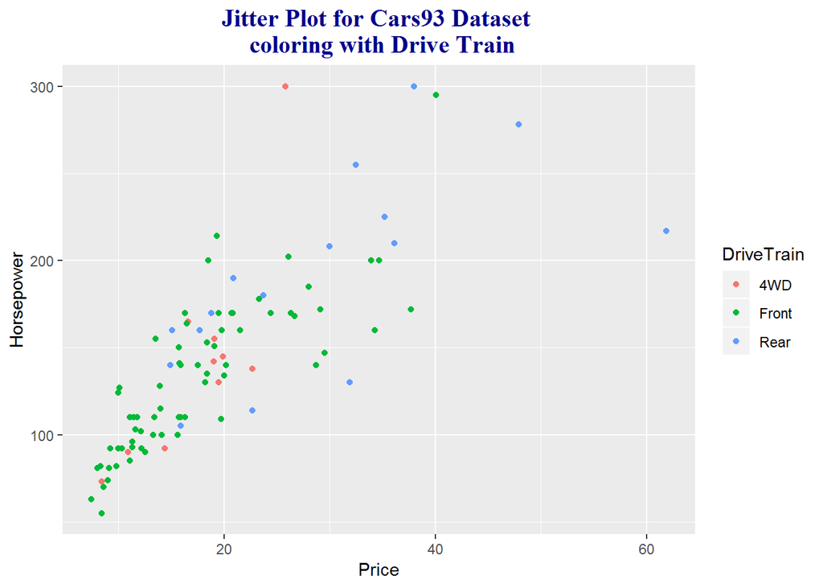

```r
Basic_Plot +
  labs(title="Jitter Plot for Cars93 Dataset \n coloring with Drive Train") + # title 명칭을 두 줄로 입력합니다.
  theme(plot.title = element_text(family = "serif", face = "bold", hjust = 0.5, size = 15, color = "darkblue"))
```

#### **2. 축(Axis) 커스텀 하기**

두 번째 내용은 그래프의 X-, Y-축(Axis)을 커스텀 하는 부분입니다.

##### **2.1 축 타이틀 꾸미기**

축의 타이틀은 기본 그래프의 “Price”, “Horsepower”에 해당합니다.  
축의 타이틀은 `element_text(family, face, size, color 등)` 을 통해 꾸밀 수 있습니다.

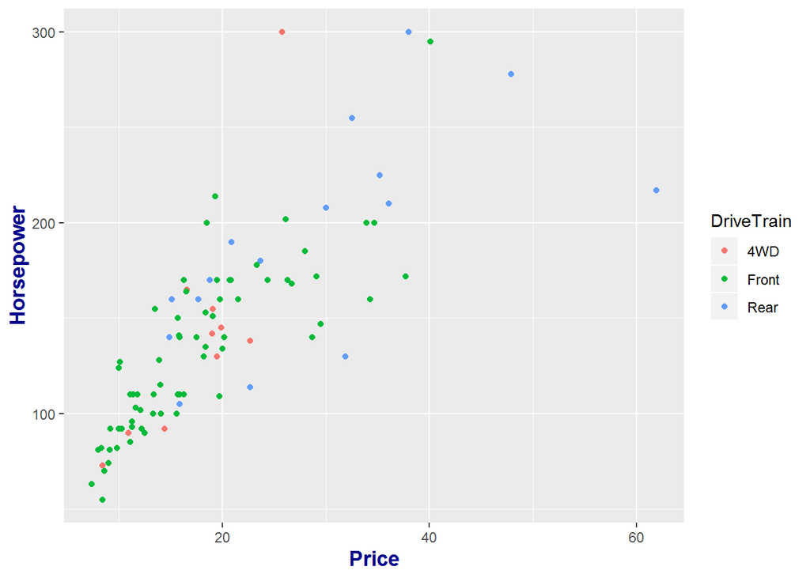

```r
Basic_Plot +
  theme(axis.title = element_text(face = "bold", size = 13, color = "darkblue"))   # 축의 글자 모양, 크기, 색상을 설정합니다.
```

##### **2.2 축 타이틀 바꾸기**

기본 그래프의 축 타이틀인 “Price”, “Horsepower”를 다른 타이틀로 바꿔봅니다.  
축의 타이틀을 입력하는 함수는 `labs()` 함수이며 X축, Y축에 대해 각각 타이틀 수정이 가능합니다.

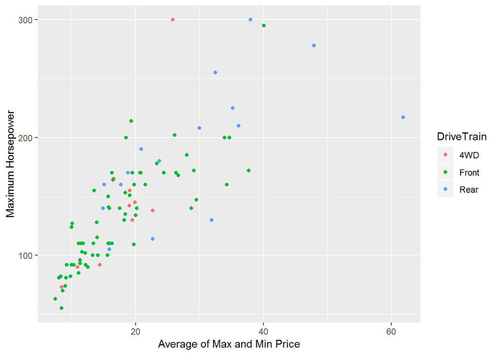

```r
Basic_Plot +
  labs(x="Average of Max and Min Price", y="Maximum Horsepower")   # 축의 타이틀을 변경합니다.
```

##### **2.3 축 타이틀에 수식 넣기**

축 타이틀을 입력하는 labs() 함수에는 기본적으로 아래 첨자, 위 첨자, 제곱 표현과 같은 수식의 입력을 제공하고 있지 않습니다.  
따라서 수식을 입력하기 위해서는 expression() 함수나 bquote() 함수의 사용이 필요합니다.  
사용 방법은 기존의 labs() 함수 내에서 수식을 입력하는 부분에 해당 함수를 삽입하면 됩니다.

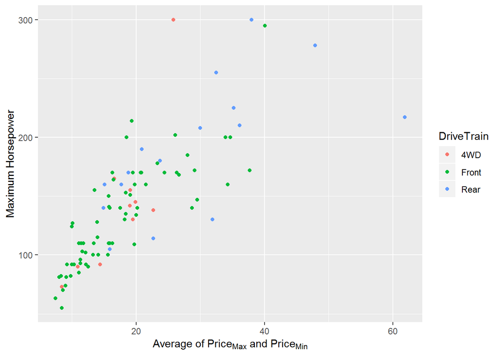

```r
Basic_Plot +
  labs(x=expression('Average of Price'['Max']*' and Price'['Min']), y="Maximum Horsepower")   # 축의 타이틀을 변경합니다. 아래 첨자 수식을 입력할 수 있도록 bquote 함수를 씁니다.
```

##### **2.4 축 표현 범위 설정하기**

이번에는 축에서 라벨이 나타나는 범위를 설정하는 예제를 진행합니다.  
기본 그래프에서는 Price를 0~60까지 표현했지만,  
이번 예제에서는 0~40까지 제한하여 그래프에 표현합니다.

이때 사용하는 함수는 lims() 함수이며, 제한하고자 하는 축의 시작과 끝 범위를 입력하면 됩니다.  
해당 함수를 사용할 때에는 데이터를 표현하는 범위를 제한하기 때문에 범위에 속하지 않는 데이터가 제거된다는 경고 메시지가 뜨게 됩니다.  
또한 제한하고자 하는 변수의 형태가 numeric이 아닌 경우에도 에러가 날 수 있습니다. 이럴 경우 y축 변수를 as.numeric을 통해 수치형 변수로 변경이 필요합니다.

```
## Warning: Removed 3 rows containing missing values (geom_point).
```

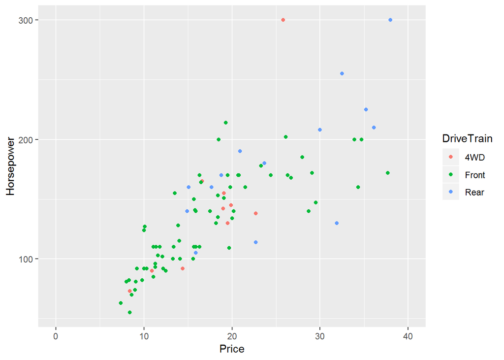

```r
Basic_Plot +
  lims(x=c(0,40))   # x축을 0에서 40까지만 나타냅니다. 데이터를 표현하는 범위를 제한했기 때문에 경고문구가 나타납니다.
```

##### **2.5 축 텍스트 잘게 쪼개기**

기본 그래프를 살펴보면 X축의 Price에 대해서 텍스트가 20, 40, 60만 나타납니다.  
이러한 텍스트를 잘게 쪼개기 위해서는 라벨이 속한 축에 따라 scale_x_continuous() 함수나 scale_y_continuous()를 사용합니다.  
해당 함수 내부의 argument 중 breaks를 통해 원하는 형태로 라벨을 쪼갤 수 있습니다.

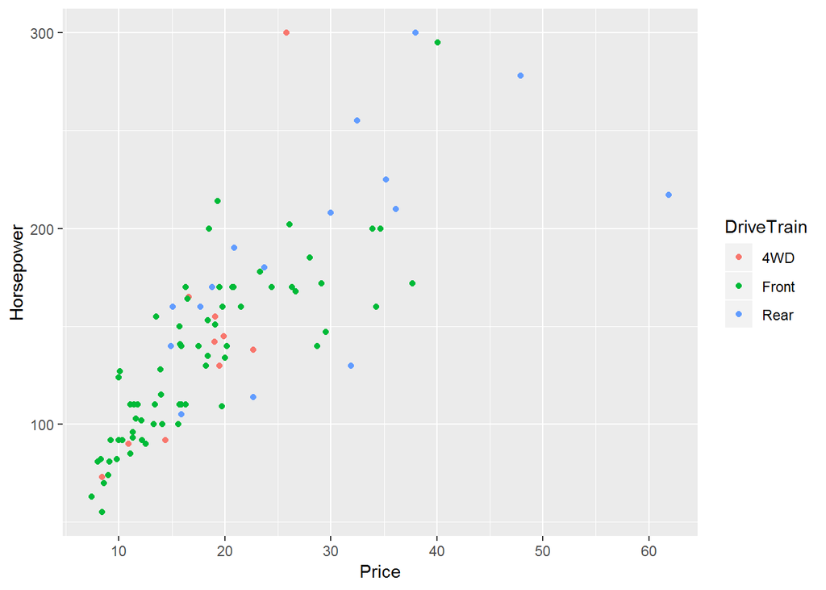

```r
Basic_Plot +
  scale_x_continuous(breaks = c(10,20,30,40,50,60))   # x축을 10단위로 쪼갭니다.
```

##### **2.6 축 텍스트 바꾸기**

이번에는 X축인 Price를 좀 더 잘 설명하기 위해 텍스트에 “$”를 붙여서 바꿔주는 예제를 진행합니다.  
텍스트의 명칭을 바꿀 때도 텍스트가 속한 축에 따라 scale_x_continuous() 함수나 scale_y_continuous()를 사용합니다.  
해당 함수 내부의 argument 중 labels를 통해 원하는 값으로 텍스트의 명칭을 변경할 수 있습니다.

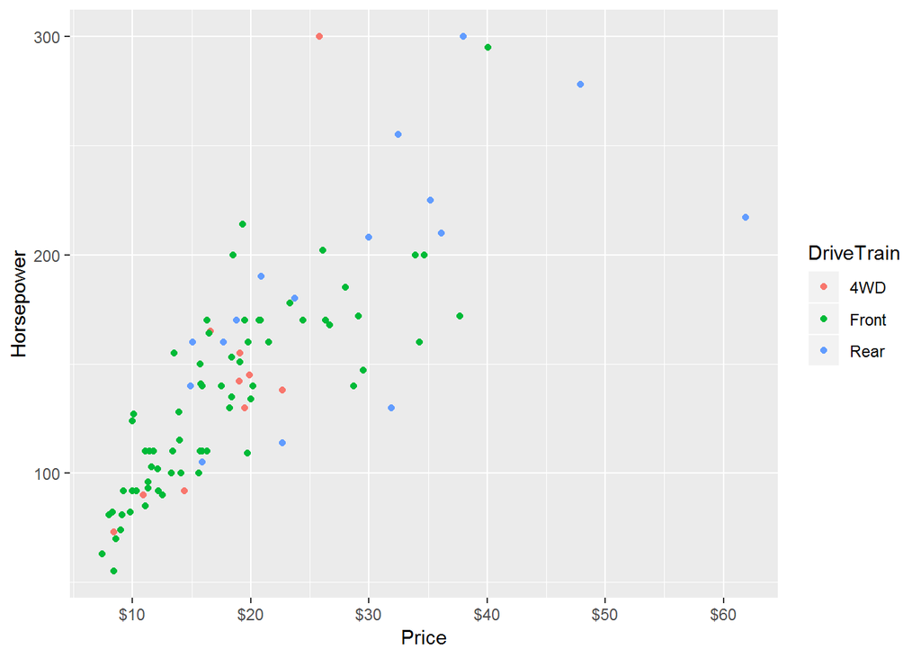

```r
Basic_Plot +
  scale_x_continuous(breaks = c(10,20,30,40,50,60), labels = paste0("$",c(10,20,30,40,50,60)))   # x축을 10단위로 쪼갭니다. 앞에 $를 붙여서 라벨 명칭을 바꿉니다.
```

##### **2.7 축 텍스트 옆으로 눕히기**

축의 텍스트을 너무 잘게 쪼개거나 각 텍스트의 명칭이 긴 경우에는 텍스트끼리 겹쳐서 보이는 문제가 발생합니다.  
이번에는 이러한 경우에 사용할 수 있는 텍스트를 옆으로 눕히는 방법에 대한 예제를 진행합니다.  
X축인 Price를 좀 더 잘게 쪼개고 “$”를 붙인 후에 이를 90도 회전시켜서 보여줍니다.  
텍스트의 입력이 아닌 형태를 바꾸는 부분에서는 theme() 함수를 사용합니다.

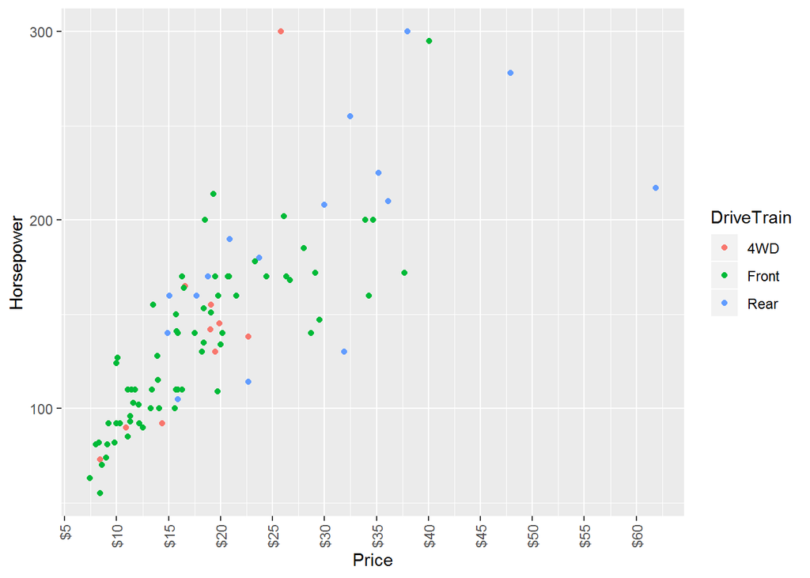

```r
Basic_Plot +
  scale_x_continuous(breaks = c(c(1:12)*5), labels = paste0("$",c(c(1:12)*5))) +   # x축을 5단위로 쪼갭니다. 앞에 $를 붙여서 텍스트의 명칭을 바꿉니다.
  theme(axis.text.x = element_text(angle = 90, hjust = 1, vjust = 0.5 ))   # x축 텍스트를 옆으로 눕힙니다.
```

##### **2.8 축 위치 바꾸기**

기본 그래프에서 X축은 아래, Y축은 좌측에 위치합니다.  
이러한 축의 위치는 X축은 위로, Y축은 우측으로 변경이 가능합니다.  
축 텍스트의 위치를 바꿀 때도 텍스트 속한 축에 따라 scale_x_continuous() 함수나 scale_y_continuous()를 사용합니다.

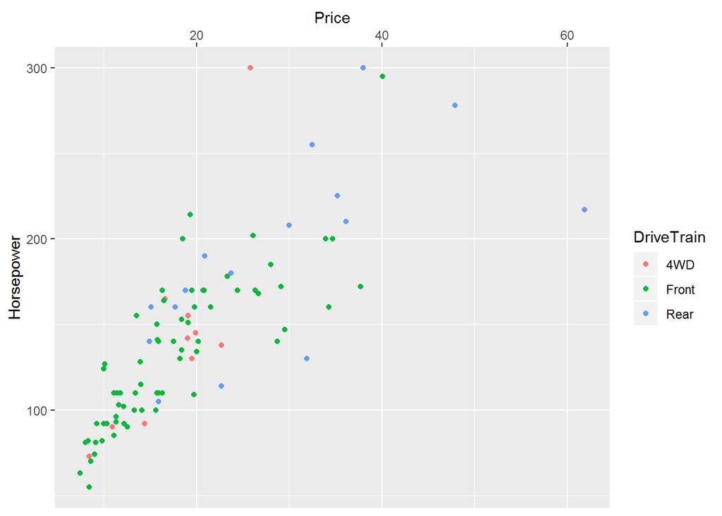

```r
Basic_Plot +
  scale_x_continuous(position = "top")   # x축을 위로 옮깁니다.
```

##### **2.9 Y축 두 개 만들기**

이번엔 `basic_plot`이 아닌 `Cars93`데이터에서 두 개의 Y축을 만들기 위해  
가격에 따른 Wheelbase와 Rear.seat.room의 선 그래프를 그려보겠습니다.  
새로운 Y2축을 만들기 위해서는 각 축의 최대값을 비율을 구해 Y2축에 곱해줘야 합니다. Y2축은 기존 Y1축을 모방해 만들기 때문입니다.  
Y2축을 만드는 방법은 아래와 같습니다.

```r
max_ratio <- max(Cars93$Wheelbase)/max(Cars93$Rear.seat.room,na.rm = T) # 새로만들 축에 곱할 y1과 y2의 최대치의 비율

str(Cars93)
```

```
## 'data.frame':    93 obs. of  27 variables:
##  $ Manufacturer      : Factor w/ 32 levels "Acura","Audi",..: 1 1 2 2 3 4 4 4 4 5 ...
##  $ Model             : Factor w/ 93 levels "100","190E","240",..: 49 56 9 1 6 24 54 74 73 35 ...
##  $ Type              : Factor w/ 6 levels "Compact","Large",..: 4 3 1 3 3 3 2 2 3 2 ...
##  $ Min.Price         : num  12.9 29.2 25.9 30.8 23.7 14.2 19.9 22.6 26.3 33 ...
##  $ Price             : num  15.9 33.9 29.1 37.7 30 15.7 20.8 23.7 26.3 34.7 ...
##  $ Max.Price         : num  18.8 38.7 32.3 44.6 36.2 17.3 21.7 24.9 26.3 36.3 ...
##  $ MPG.city          : int  25 18 20 19 22 22 19 16 19 16 ...
##  $ MPG.highway       : int  31 25 26 26 30 31 28 25 27 25 ...
##  $ AirBags           : Factor w/ 3 levels "Driver & Passenger",..: 3 1 2 1 2 2 2 2 2 2 ...
##  $ DriveTrain        : Factor w/ 3 levels "4WD","Front",..: 2 2 2 2 3 2 2 3 2 2 ...
##  $ Cylinders         : Factor w/ 6 levels "3","4","5","6",..: 2 4 4 4 2 2 4 4 4 5 ...
##  $ EngineSize        : num  1.8 3.2 2.8 2.8 3.5 2.2 3.8 5.7 3.8 4.9 ...
##  $ Horsepower        : int  140 200 172 172 208 110 170 180 170 200 ...
##  $ RPM               : int  6300 5500 5500 5500 5700 5200 4800 4000 4800 4100 ...
##  $ Rev.per.mile      : int  2890 2335 2280 2535 2545 2565 1570 1320 1690 1510 ...
##  $ Man.trans.avail   : Factor w/ 2 levels "No","Yes": 2 2 2 2 2 1 1 1 1 1 ...
##  $ Fuel.tank.capacity: num  13.2 18 16.9 21.1 21.1 16.4 18 23 18.8 18 ...
##  $ Passengers        : int  5 5 5 6 4 6 6 6 5 6 ...
##  $ Length            : int  177 195 180 193 186 189 200 216 198 206 ...
##  $ Wheelbase         : int  102 115 102 106 109 105 111 116 108 114 ...
##  $ Width             : int  68 71 67 70 69 69 74 78 73 73 ...
##  $ Turn.circle       : int  37 38 37 37 39 41 42 45 41 43 ...
##  $ Rear.seat.room    : num  26.5 30 28 31 27 28 30.5 30.5 26.5 35 ...
##  $ Luggage.room      : int  11 15 14 17 13 16 17 21 14 18 ...
##  $ Weight            : int  2705 3560 3375 3405 3640 2880 3470 4105 3495 3620 ...
##  $ Origin            : Factor w/ 2 levels "USA","non-USA": 2 2 2 2 2 1 1 1 1 1 ...
##  $ Make              : Factor w/ 93 levels "Acura Integra",..: 1 2 4 3 5 6 7 9 8 10 ...
```

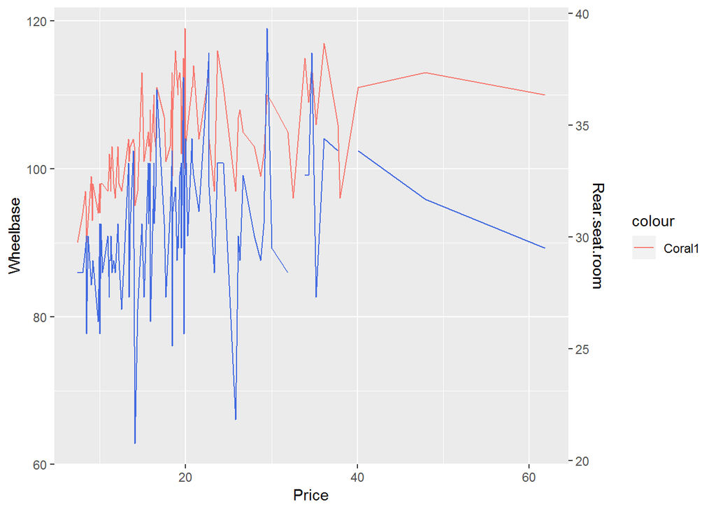

```r
ggplot(Cars93, aes(x=Price)) +
  geom_line(aes(y=Wheelbase, color="Coral1")) +
  geom_line(aes(y=Rear.seat.room*max_ratio), color="Royalblue") + # Rear.seat.room에 max_ratio를 곱해 y2 그리그
  scale_y_continuous(sec.axis = sec_axis(~.*(max_ratio/10), name = "Rear.seat.room")) # sec_axis는 첫번째 축을 기준으로 만듦
```

```r
                                                                                      # 10으로 나눈 이유는 y1과 y2의 단위를 맞춰주기 위함
```

#### **3. 범례(Legend) 커스텀 하기**

세 번째 내용은 그래프의 범례(Legend)를 커스텀 하는 부분입니다.

##### **3.1 범례 지우기**

기본 그래프에서는 색상을 지정하게 되면 우측의 범례가 나타납니다.  
이러한 범례는 필요에 따라 지우는 게 가능합니다.  
범례를 지우기 위해서는 theme() 함수를 통해서 설정을 해주어야 합니다.

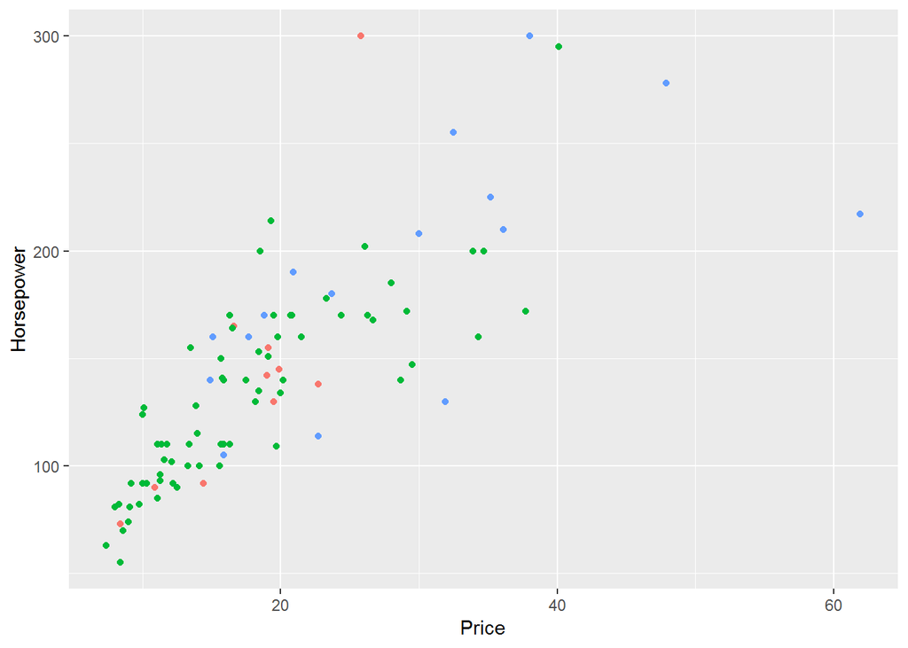

```r
Basic_Plot + theme(legend.position = "none")   # 범례를 지웁니다.
```

##### **3.2 범례 꾸미기**

범례도 축이나 타이틀과 같이 theme() 함수를 통해 꾸미는 것이 가능합니다.  
이번에는 범례에서 수정이 가능한 항목인 타이틀과 키(key: 색상이나 도형), 텍스트를 꾸미는 예제를 진행합니다.

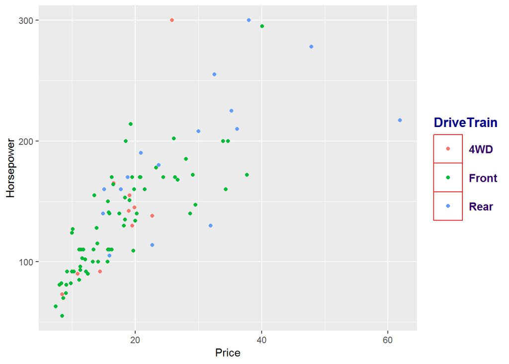

```r
Basic_Plot +
  theme(legend.title = element_text(face = "bold", size = 13, color = "darkblue")) +   # 범례 타이틀의 글자 모양, 크기, 색상을 설정합니다.
  theme(legend.text = element_text(face = "bold", size = 11, color = "#330066")) +    # 범례 항목 글자의 글자 모양, 크기, 색상을 설정합니다.
  theme(legend.key = element_rect(color = "red", fill = "white"), legend.key.size = unit(1,"cm"))   # 범례 항목 아이콘의 테두리 색상, 내부 색상, 크기를 설정합니다.
```

##### **3.3 범례 테두리 꾸미기**

범례는 추가적으로 범례의 테두리도 theme() 함수를 통해 꾸미는 것이 가능합니다.  
범례의 테두리를 꾸미는 코드와 결과는 다음과 같습니다.

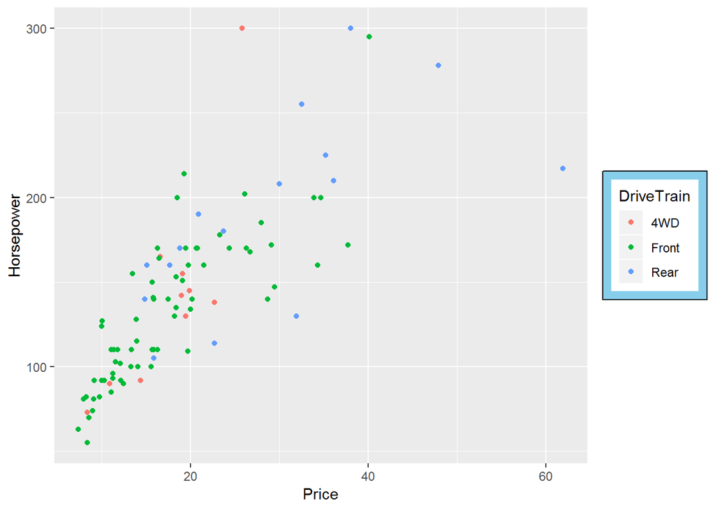

```r
Basic_Plot +
  theme(legend.box.background = element_rect(fill = "skyblue"), legend.box.margin = margin(6, 6, 6, 6))   # 범례의 테두리의 색상, 여백 크기를 설정합니다.
```

##### **3.4 범례 위치 바꾸기**

범례 위치도 축과 같이 위치를 바꾸는 것이 가능합니다.  
범례의 경우는 축과 달리 theme() 함수를 통해 위치를 바꾸어 주어야 하며 위치는 위, 아래, 우측, 좌측 모두 가능합니다.

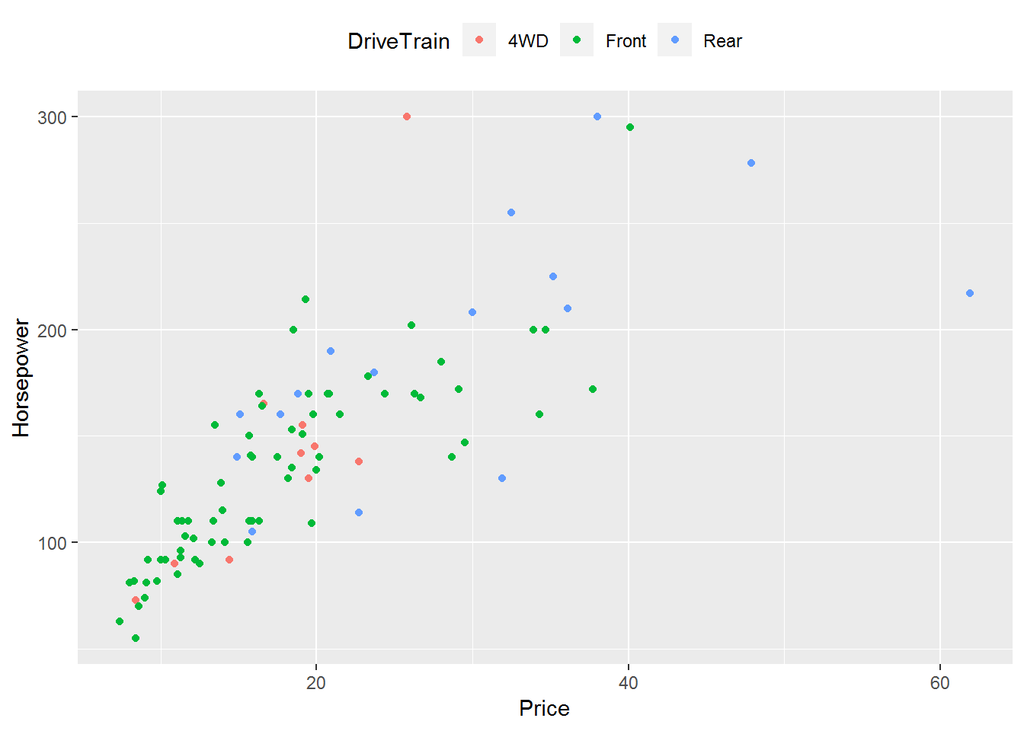

```r
Basic_Plot +
  theme(legend.position = "top")   # 범례 위치를 설정합니다.
```

##### **3.5 범례 위치를 그래프 안으로 넣기**

범례 위치는 그래프 외부에서 바꾸는 것 외에 그래프 내부로 가져오는 것도 가능합니다.  
동일하게 theme() 함수에서 그래프 내부의 X, Y 좌표를 설정함으로써 그래프 내부로 옮깁니다.

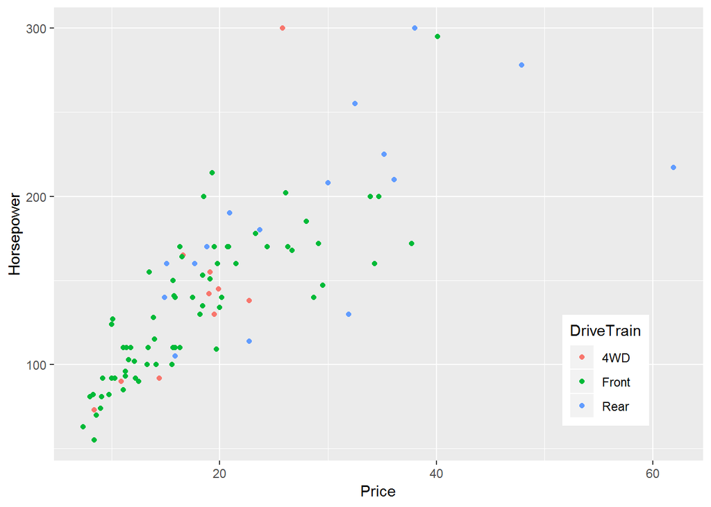

```r
Basic_Plot +
  theme(legend.position = c(0.85, 0.2))   # 범례 위치를 그래프 내부로 설정합니다.
```

##### **3.6 범례 타이틀만 지우기**

범례 전체를 지우는 것 외에 범례의 타이틀만 제거하는 것도 가능합니다.  
범례의 타이틀만 제거할 때에는 범례의 제거와는 달리 theme() 함수에서 element_blank()를 입력해야 합니다.

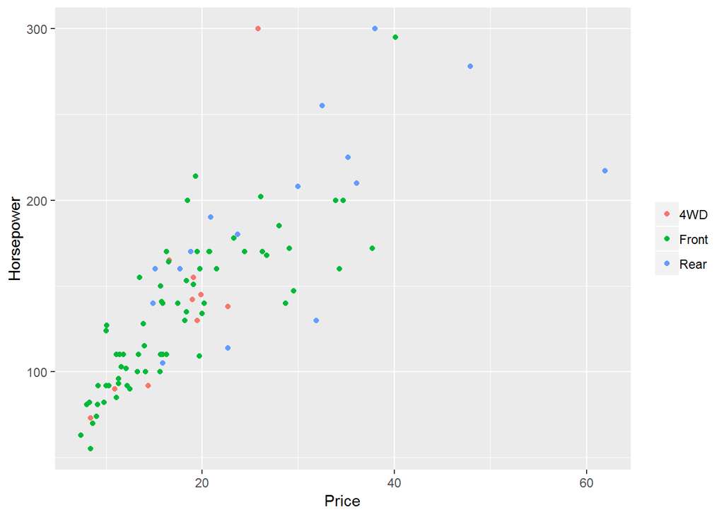

```r
Basic_Plot +
  theme(legend.title = element_blank())   # 범례의 타이틀을 지웁니다.
```

##### **3.7 범례 타이틀 바꾸기**

범례도 타이틀을 바꾸는 것이 가능합니다.  
범례의 타이틀을 바꿀 때에는 범례가 연속형인지 범주형인지에 따라서 scale_color_continuous()이나 scale_color_discrete()을 사용합니다.  
각 함수 내에서 name에 원하는 타이틀을 입력하면 됩니다.

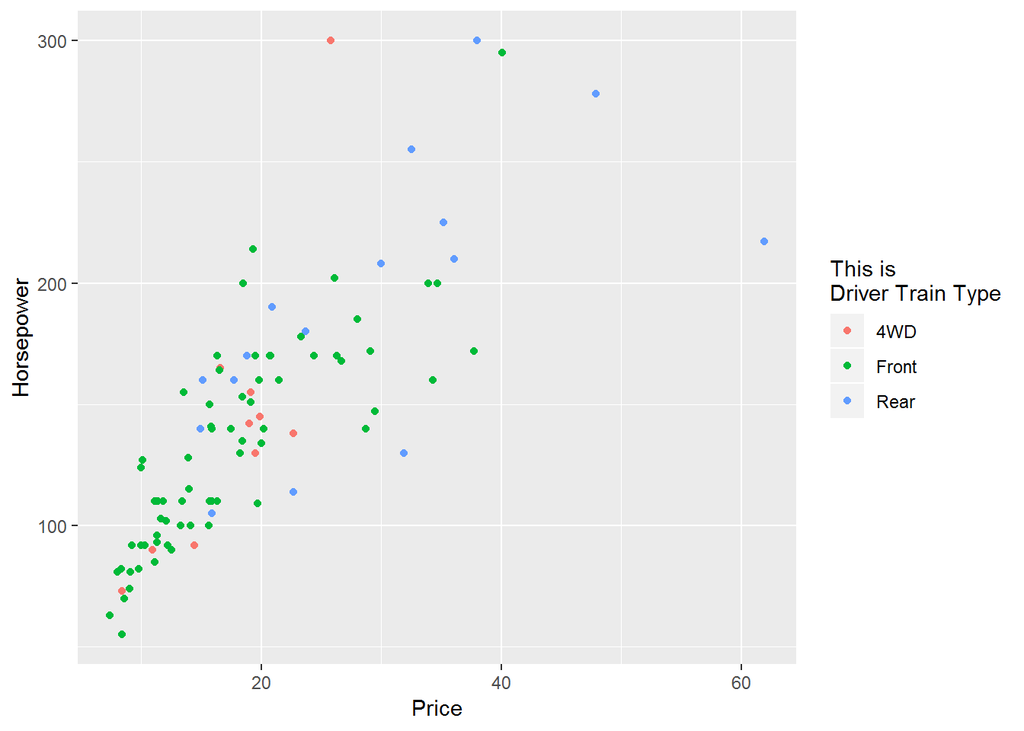

```r
Basic_Plot +
  scale_color_discrete(name="This is\nDriver Train Type")   # 범례의 타이틀을 바꿉니다.
```

#### **4. 그래프(plot) 커스텀 하기**

그래프 내부를 커스텀 하는 부분입니다.

##### **4.1 그래프 안에 글자/선/도형 넣기**

annotate() 함수를 통해 그래프 안에 글자나 선, 도형 등의 추가가 가능합니다.  
한 번에 여러 개의 항목을 추가할 수도 있으며 도형 위에 글자나 선을 넣는 것도 가능합니다.  
그래프 안에 글자, 선, 사각형 도형을 넣는 코드와 결과는 다음과 같습니다.

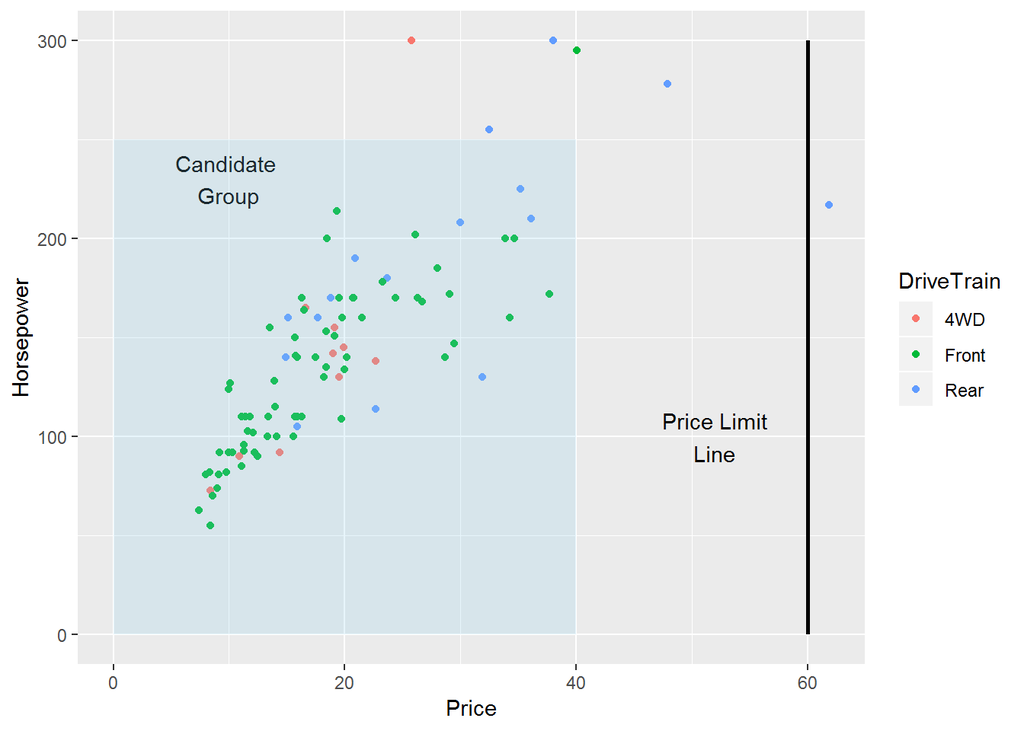

```r
Basic_Plot +
  annotate("text", x = 52, y = 100, label = "Price Limit\nLine") +   # plot에 글자를 추가합니다.
  annotate("text", x = 10, y = 230, label = "Candidate \nGroup") +   # plot에 글자를 추가합니다.
  annotate("rect", xmin = 0, xmax = 40, ymin = 0, ymax = 250, alpha = .2, fill="skyblue") +   # plot에 사각형을 추가합니다.
  annotate("segment", x = 60, xend = 60, y = 0, yend = 300, colour = "black", size=1)   # plot에 선을 추가합니다.
```

##### **4.2 그래프X축, Y축 바꿔 그리기**

그래프의 X, Y축을 뒤집어 그리는 것은 coord_flip() 함수를 통해 쉽게 가능합니다.  
coord_flip() 함수를 사용하면 뒤집어 그리기 위해 일부러 다른 형태의 그래프를 그릴 필요 없이  
기존의 그래프에서 X, Y축만 뒤집어 그릴 수 있습니다.

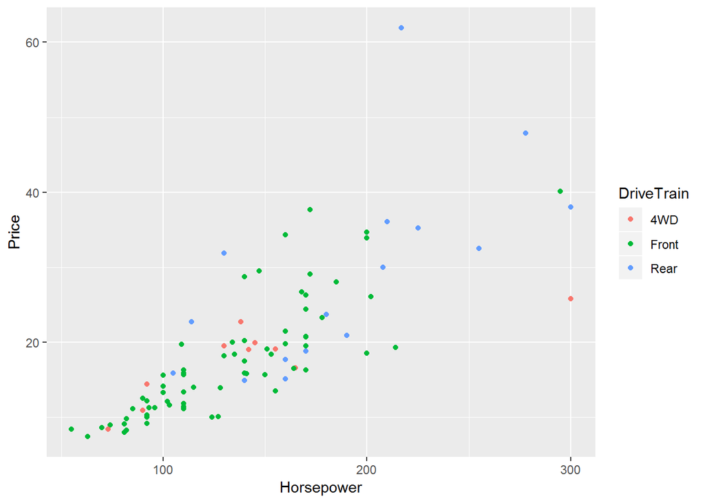

```r
Basic_Plot +
  coord_flip()   # x축, y축을 바꿔서 그립니다.
```

##### **4.3 흑백으로 나타내기**

필요에 의해서 칼라 색상을 사용할 수 없는 경우에는 그래프의 색상을 흑백으로 바꿔주는 것이 필요합니다.  
이때에는 scale_colour_grey() 함수를 통해 쉽게 흑백 변경이 가능합니다.  
그래프의 색상을 흑백으로 바꿔주는 코드와 결과는 다음과 같습니다.

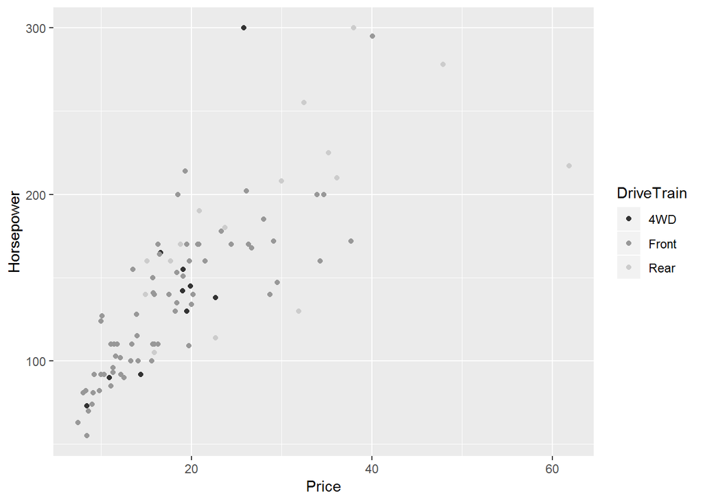

```r
Basic_Plot +
  scale_colour_grey()   # 흑백으로 나타냅니다.
```

##### **4.4 팔레트 적용하기**

기본으로 부여되는 색상이 마음에 들지 않는 경우에는 ggplot2에서 제공하는 팔레트를 사용하여 변경할 수 있습니다.  
이때에는 scale_color_brewer() 함수에서 palette 입력을 통해 쉽게 색상의 변경이 가능합니다.  
사용이 가능한 팔레트의 종류는 매우 다양하며 여기 에서 확인이 가능합니다.

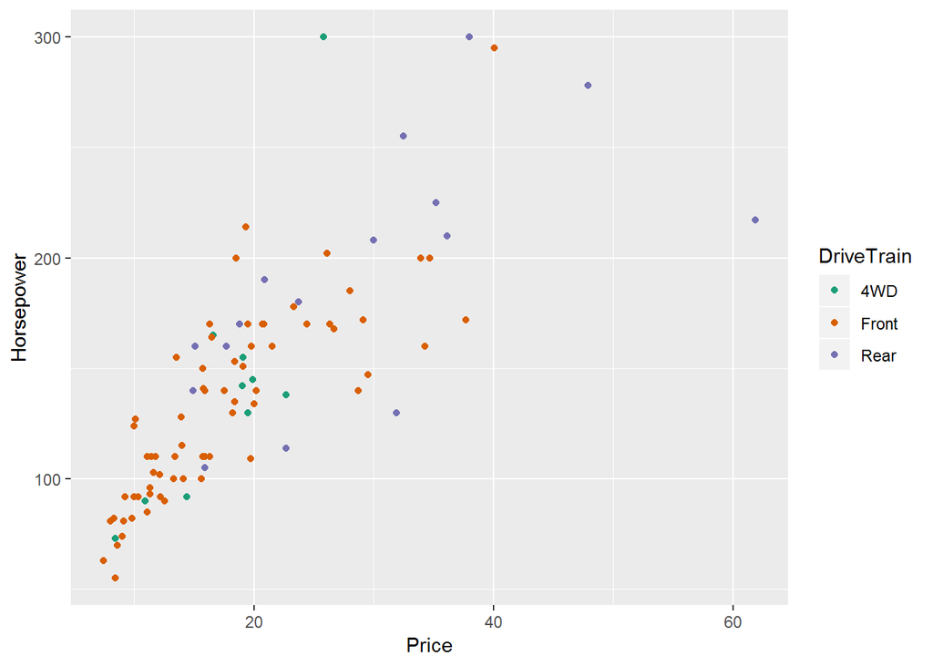

```r
Basic_Plot +
  scale_color_brewer(palette = "Dark2")  # Dark2 팔레트를 적용합니다.
```

##### **4.5 원하는 색상으로 바꾸기**

팔레트에도 원하는 색상이 없는 경우에는 직접 자신이 원하는 색상을 입력하여 변경하는 것도 가능합니다.  
이때에는 scale_color_manual() 함수에서 색상 값의 입력을 통해 색상의 변경이 가능합니다.  
주의해야 할 부분은 입력된 색상 값의 수가 범례의 항목 수와 동일해야 한다는 점입니다.  
입력한 색상의 수가 범례의 항목 수와 다를 경우에는 에러가 나면서 색상 변경이 적용되지 않습니다.

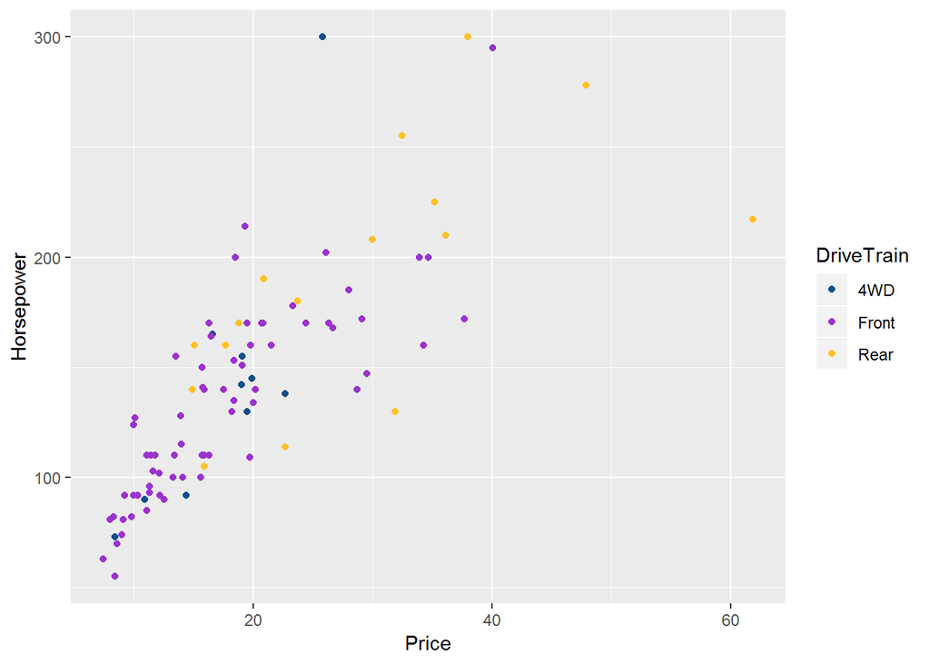

```r
Basic_Plot +
  scale_color_manual(values = c("dodgerblue4", "darkorchid3", "goldenrod1"))  # 원하는 색상으로 표현합니다.
```

##### **4.6 테마 적용하기**

그래프의 색상이 아니라 전체적인 변화를 시도하고 싶은 경우에는 “ggthemes” 패키지를 통해 테마 변경이 가능합니다.  
패키지를 설치한 후에 기존의 그래프에 원하는 테마를 덧붙이는 것만으로 쉽게 변경이 가능합니다.  
적용할 수 있는 테마는 아래의 사이트에서 살펴볼 수 있습니다.

[ggthemes종류](https://yutannihilation.github.io/allYourFigureAreBelongToUs/ggthemes/)  
[ggthemes예제](https://mran.microsoft.com/snapshot/2016-12-03/web/packages/ggthemes/vignettes/ggthemes.html)

```r
library(ggthemes)
```

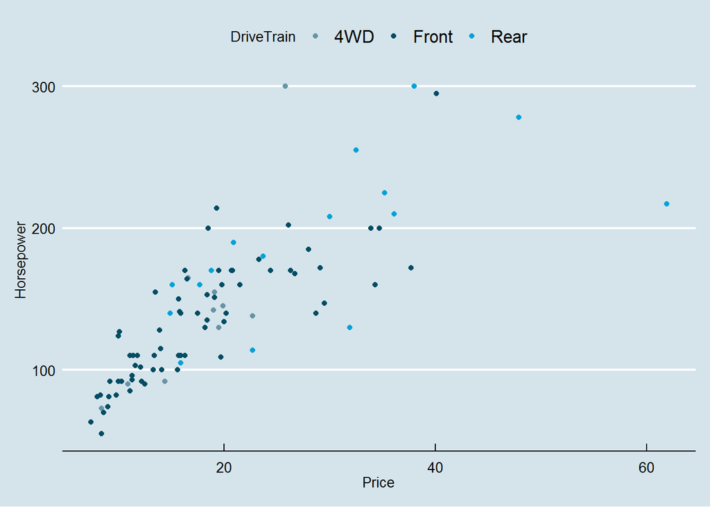

```r
Basic_Plot +
  scale_color_economist() +
  theme_economist()   # economist 테마를 적용합니다.
```

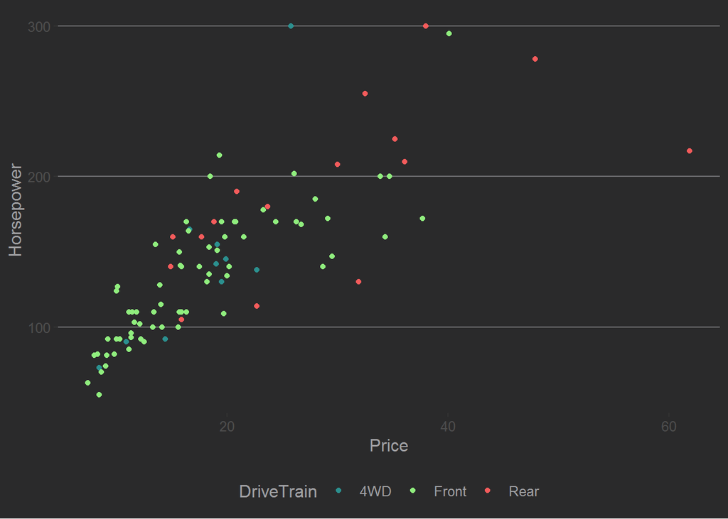

```r
Basic_Plot +
  theme_hc(bgcolor = "darkunica") +
  scale_colour_hc("darkunica")   # darkunica 색상의 Highcharts 테마를 적용합니다.
```

#### **5. 좌표계(coordinate) 커스텀 하기**

##### **5.1 좌표계란**

좌표계(座標系, coordinate system)는 하나 이상의 숫자 또는 좌표를 사용하여 유클리드 공간과 같은 다양체에서  
점 또는 기타 기하학적 요소의 위치를 고유하게 결정하는 시스템입니다.

가장 단순한 좌표계는 직교 좌표로 알려진 서로 수직으로 향한 좌표축(아래 그림)입니다. 여러 좌표계가 있지만, 그 중에서 우리는 직교 좌표계(카테시안 좌표계)를 알아보겠습니다.

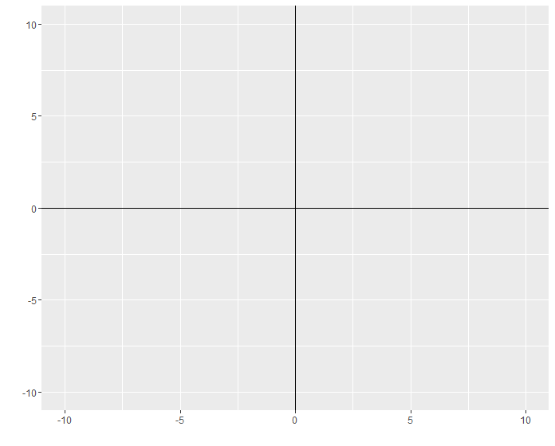

ggplot2를 사용해 만든 일반적인 직교좌표계

##### **5.2 coord_cartesian 함수**

*“저 파리의 위치를 어떻게 하면 표현 할 수 있을까?”*

ggplot2에서는 여러가지 좌표계를 지원합니다.  
그중에서 앞서 설명한, 흔히 직교 좌표계라고 부르는 데카르트 좌표계의 설정을 변경하는 함수를 알아보겠습니다.  
ggplot2에서는 coord_cartesian 함수를 통해 데카르트 좌표계의 X, Y축을 변경할 수 있으며 xlim, ylim, expand 세가지 인자를 가지고 있습니다.

##### **5.2.1 xlim과 ylim**

x축과 y축의 범위를 제한 할 때 사용합니다.  
x축과 y축에 들어가는 데이터를 제한하는 것이 아니라 돋보기를 쓰고 축을 확대하는 개념입니다.  
설명을 위해 R 내장 데이터인 faithful데이터를 사용하겠습니다. faithful 데이터는 미국 옐로스톤 국립공원의 올드 페이스 풀 간헐천의 분화와 분화 사이의 대기시간을 기록한 데이터입니다.

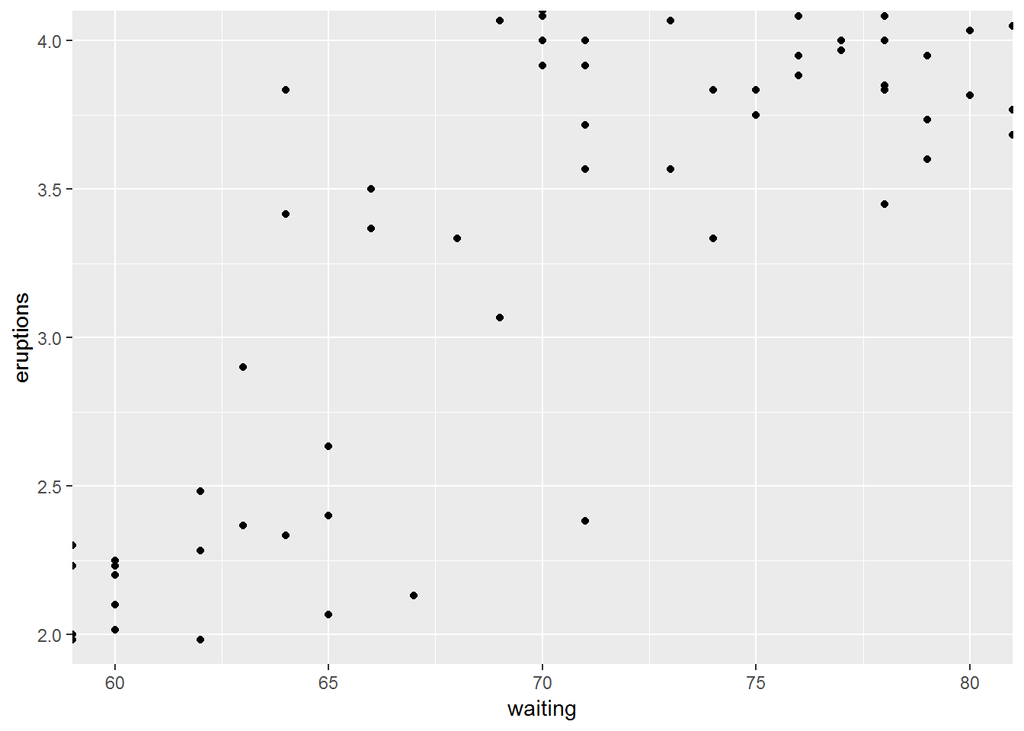

```r
library(ggplot2)

ggplot(faithful, aes(waiting, eruptions))+
  geom_point()+
  coord_cartesian(xlim = c(60, 80), ylim = c(2:4))
```

xlim과 ylim을 통해서 x축은 60에서 80까지, y축은 2에서 4까지의 범위를 지정했습니다.  
위의 사례처럼 절대값(직접 숫자 지정)을 지정해서 범위를 제한 할 수도 있지만 아래와 같이 상대값(min, max)을 활용하여 지정해 줄 수도 있습니다.

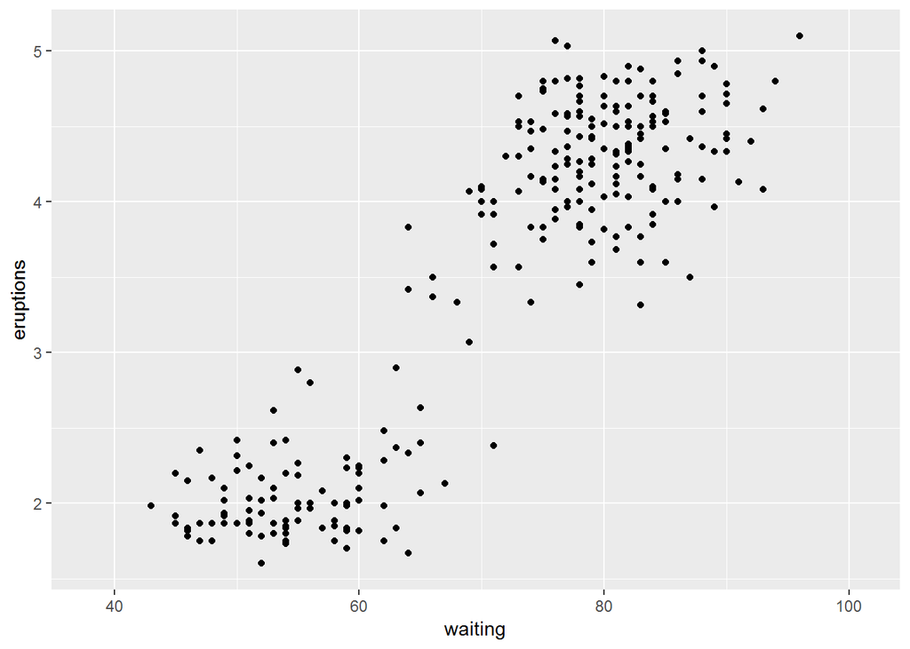

```r
library(ggplot2)

ggplot(faithful, aes(waiting, eruptions))+
  geom_point()+
  coord_cartesian(xlim = c(min(faithful$waiting)-5, max(faithful$waiting)+5))
```

위의 그래프에서 x축의 범위를 상대값으로 지정해 주었습니다.  
위의 코드를 살펴보면 x축은 faithful데이터의 waiting열의 최소값에서 5만큼 뺀 값에서 faithful데이터의 waiting열의 최대값에서 5만큼 더한 값까지로 설정되어있습니다.  
이렇듯 상대값으로 지정되면 데이터가 수정되더라도 언제나 안정적인 범위를 출력 할 수 있습니다.

##### **5.2.2 expand**

축과 데이터의 겹침을 방지하여 데이터를 플롯에 온전히 표기하기 위해 약간의 여백을 주는 인자입니다.  
디폴트값(초기값)은 TRUE로 설정되어 있으며 FALSE로 설정 시 그래프의 여백이 사라지게 됩니다.

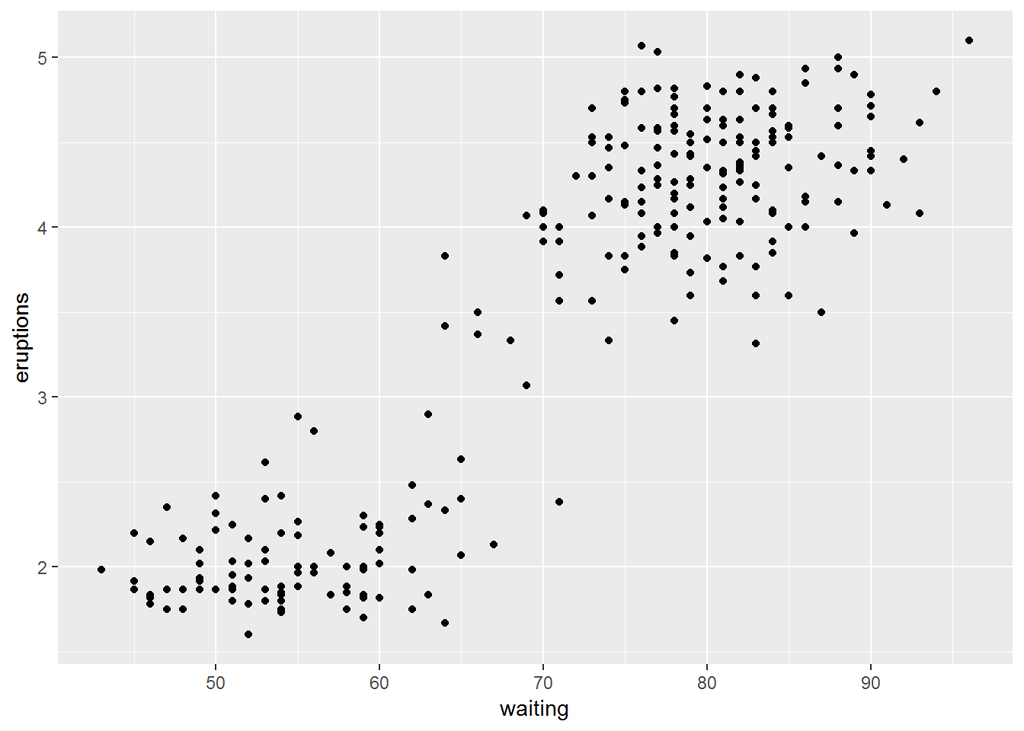

```r
library(ggplot2)

ggplot(faithful, aes(waiting, eruptions))+
  geom_point()+
  coord_cartesian(expand = TRUE)
```

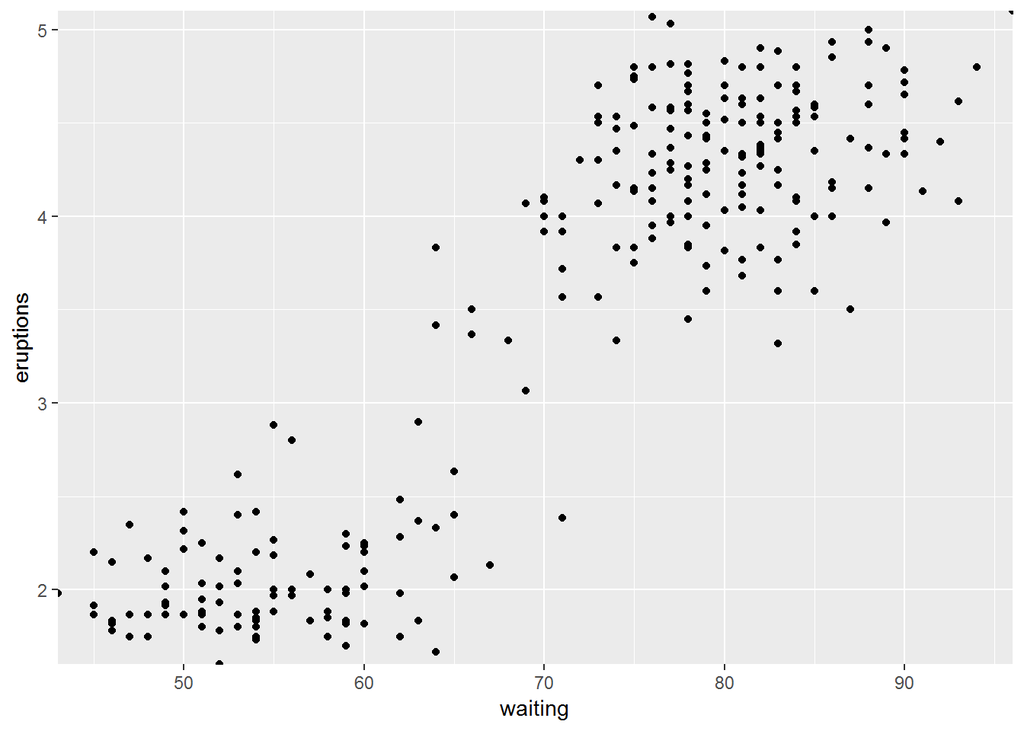

```r
library(ggplot2)

ggplot(faithful, aes(waiting, eruptions))+
  geom_point()+
  coord_cartesian(expand = FALSE)
```

위의 첫 번째 그래프는 expand를 TRUE로 설정한 그래프입니다. 데이터와 축 사이의 여백이 있음을 알 수 있습니다.  
그러나 두 번째 그래프는 여백이 없음을 알 수 있습니다.

##### **5.3.3 scale_x_continuous와 차이점**

ggplot2에서 축을 설정하는 함수는 scale_x_continuous, xlim 등 여러가지가 있습니다.  
그러나 이들과 coord_cartesian 사이에는 차이점이 있습니다. 우선 coord_cartesian은 데카르트 좌표계를 설정합니다.  
그래서 coord_cartesian함수를 사용하여 x와 y값을 지정하면 단순히 출력되는 좌표계의 범위를 지정하는 것을 의미합니다.  
일종의 좌표평면 확대로 생각하면 이해하기 쉽습니다. 그러나 scale_x_continuous에서 limit으로 수정하거나 xlim을 사용하면 지정 범위 밖에 있는 데이터를 관측에서 제외합니다.  
이해를 돕기 위해 히스토그램 그래프로 예시를 들겠습니다. 두 그래프 다 x축의 범위를 60에서 80으로 설정하였습니다.

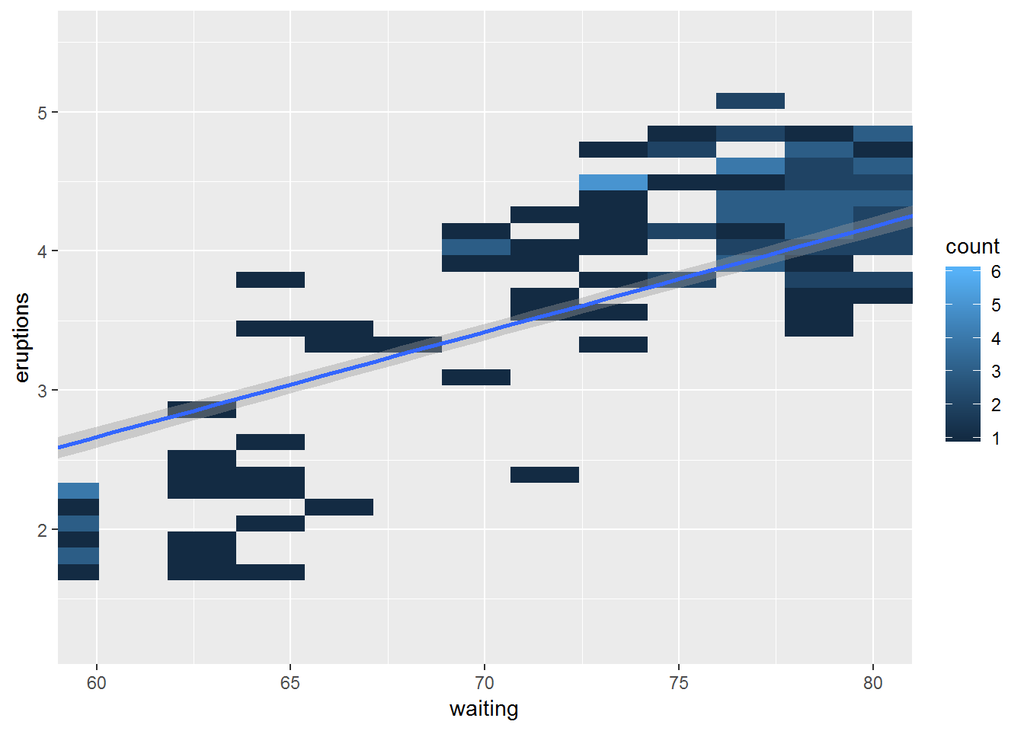

```r
library(ggplot2)

ggplot(faithful, aes(waiting, eruptions))+
  geom_bin2d()+
  coord_cartesian(xlim = c(60, 80))+
  geom_smooth(method = lm)
```

coord_cartesian함수를 사용하여 x축의 범위를 지정했습니다. 앞서 설명한 것처럼 단순히 좌표축을 확대한 것에 불가하기에 히스토그램의 모양 잡아 당긴 것처럼 변형되었습니다.  
그리고 faithful전체 데이터를 대상으로 하기 때문에 count의 최대값이 6으로 지정되어있습니다.

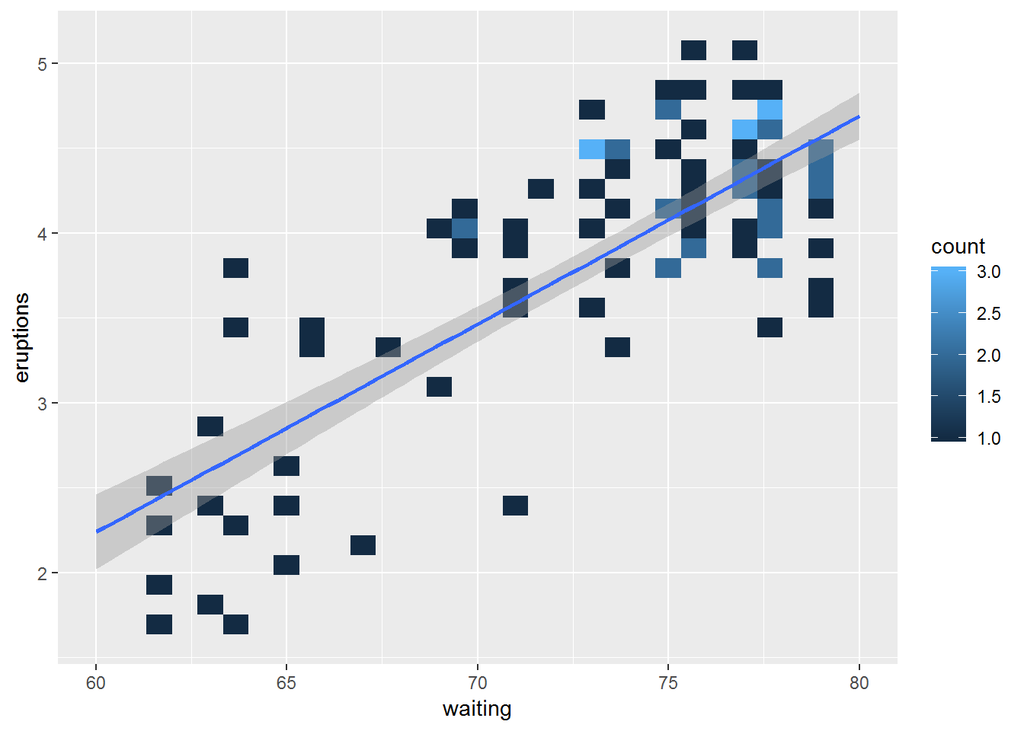

```r
library(ggplot2)

ggplot(faithful, aes(waiting, eruptions))+
  geom_bin2d()+
  scale_x_continuous(limits = c(60, 80))+
  geom_smooth(method = lm)
```

그러나 scale_x_continuous를 사용한 두 번째 그래프를 보면 확연한 차이를 보입니다.  
지정한 x축 범위를 초과하는 값은 계산에서 배제되어 히스토그램의 모양이 온전합니다.  
또한 범위에 속해있는 데이터만 분석하기 때문에 count의 최대값이 3에 머물러 있는 것을 알 수 있습니다.

단순히 그래프의 축을 확대하려면 coord_cartesian 함수를 사용하면 되지만, 그래프에 출력되는 데이터 자체를 수정하려면 scale_x_continuous 함수를 사용하면 됩니다.

#### **[부록] them 함수의 elements 설명**

| Element | 설명 | 함수 구성요소 및 기본 설정 |
| --- | --- | --- |
| `element_blank` | 아무것도 그리지 않음 | element_blank |
| `element_rect` | 테두리와 배경 | fill 배경 채움 색상, color 색상, size 크기, linetype 선 종류, inherit.blank 상위 element의 blank 상속여부 |
| `element_line` | 선 | color 색상, size 크기, linetype 선 종류, lineend 선 끝 스타일, arrow 화살표 종류, inherit.blank 상위 element의 blank 상속여부 |
| `element_text` | 글자 | family 글자종류, face 글자모양, color, size, hjust 수평맞춤, vjust 수직 맞춤, angle 각도, lineheight 선 높이, margin 글자주위공간, debug 디버깅 여부, inherit.blank |

### **참고자료**

[ggplot2 그래프 커스텀 하기](http://blog.naver.com/PostView.nhn?blogId=nife0719&logNo=221000580841)

[R - ggplot2(coder1252님의 블로그)](https://m.blog.naver.com/coder1252/220931262683)